# Лабораторная работа №7: Дискретно-событийное моделирование

Автор

принадлежность

Федорова Анжелика Игоревна

Российский университет дружбы народов

# 1 Цель работы

Реализовать модели дискретно-событийного моделирования: систему массового обслуживания M/M/c и модель Росса (система с резервом и ремонтом), выполнить симуляции, провести параметрические эксперименты и сравнить результаты с аналитическими решениями.

# 2 Задание

В ходе работы необходимо:

1. Создать рабочий каталог и структуру проекта DrWatson
2. Установить необходимые пакеты
3. Реализовать модель M/M/c и добавить графики
4. Реализовать модель Росса с несколькими ремонтниками
5. Провести прогоны для разного количества машин и ремонтников
6. Построить графики изменения характеристик системы
7. Сравнить симуляцию с аналитическим решением
8. Оформить отчёт

# 3 Ход работы

## 3.1 1. Подготовка проекта

Была создана структура проекта с использованием DrWatson:

```julia
using DrWatson
initialize_project("project"; authors=["Федорова Анжелика Игоревна"])
```

Структура проекта:

- `scripts/` — исполняемые скрипты симуляций
- `plots/` — графики результатов
- `data/sims/` — сохранённые результаты прогонов

Установлены необходимые пакеты:

```julia
using Pkg
Pkg.add([
  "DrWatson", "StableRNGs", "Distributions",
  "ConcurrentSim", "ResumableFunctions",
  "CairoMakie", "Statistics", "JLD2"
])
```

## 3.2 2. Модель M/M/c

### 3.2.1 Описание модели

Модель M/M/c (по классификации Кендалла) — система массового обслуживания со следующими свойствами:

- **M** — входящий поток заявок пуассоновский, интервалы между прибытиями распределены экспоненциально с параметром λ
- **M** — время обслуживания каждой заявки распределено экспоненциально с параметром μ
- **c** — количество идентичных обслуживающих каналов, работающих параллельно

Условие стационарности: ρ = λ/(c·μ) < 1.

### 3.2.2 Аналитические формулы

Вероятность простоя всех каналов:

$$P_0 = \left[\sum_{n=0}^{c-1}\frac{(c\rho)^n}{n!} + \frac{(c\rho)^c}{c!(1-\rho)}\right]^{-1}$$

Среднее время ожидания в очереди (формула Эрланга + Литтл):

$$W_q = \frac{L_q}{\lambda}, \quad L_q = \frac{\rho}{1-\rho} P_{\text{wait}}$$

### 3.2.3 Реализация

Скрипт `scripts/mmc_simulation.jl` реализует модель с использованием DrWatson и CairoMakie.

```julia
using DrWatson
@quickactivate "project"

using StableRNGs, Distributions, ConcurrentSim, ResumableFunctions
using CairoMakie, Statistics

@resumable function customer(
    env::Environment, server::Resource, id::Integer,
    t_a::Float64, d_s::Distribution, rng,
    wait_times::Vector{Float64},
)
    @yield timeout(env, t_a)
    t_arrive = now(env)
    @yield request(server)
    push!(wait_times, now(env) - t_arrive)
    @yield timeout(env, rand(rng, d_s))
    @yield unlock(server)
end

function run_mmc(; num_servers=2, mu=0.5, lam=0.9,
                   num_customers=500, seed=123)
    rng          = StableRNG(seed)
    arrival_dist = Exponential(1 / lam)
    service_dist = Exponential(1 / mu)
    wait_times   = Float64[]
    sim    = Simulation()
    server = Resource(sim, num_servers)
    arrival_time = 0.0
    for i in 1:num_customers
        arrival_time += rand(rng, arrival_dist)
        @process customer(sim, server, i, arrival_time,
                          service_dist, rng, wait_times)
    end
    run(sim)
    return wait_times
end
```

### 3.2.4 Скриншот выполнения скрипта

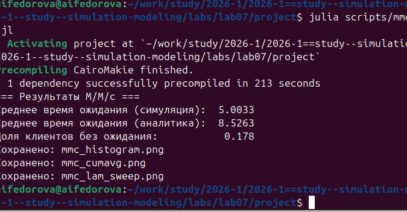

Терминал: завершение скрипта mmc_simulation.jl